# P value payoff schemes

This is an attempt to sort out the relationship between p values and payoff schemes.

## Setup

```r
library(ggplot2)
library(dplyr)
library(tidybayes)
library(purrr)
library(tidyr)
library(gganimate)
library(ggrepel)
```

## Analytical payoff expectations

**NOTE: There is an error in here somewhere as it does not currently match the simulated output**

Here we’ll try to derive what the expected payoff is given a particular strategy and the probability that the null is true. “strategies” in this case refer to choosing to reject at a given alpha level and p value correction (such as “raw”—no correction—Bonferronni, Benjamini-Hochberg, etc).

We’ll start by deriving the expected payoff in terms of the expected number of entries in each of the four corners of the confusion matrix:

$$\begin{align}
p_{null} &: \textit{prior probability of the null} \\
n &: \textit{number of choices the user must make (number of stimuli)} \\
n_{greater} &: \textit{number of the stimuli where true mean is greater than 0} \\
n_{reject} &: \textit{number of the stimuli where user says the mean is greater} \\
\\
n &= n_{greater\land reject} + n_{\neg greater \land reject} + n_{greater \land \neg reject} + n_{\neg greater \land \neg reject} \\
\\
FDR &= E\left[\frac{n_{greater \land reject}}{n_{reject}} \middle| n_{reject} > 0 \right]P(n_{reject} > 0) \\
payoff &= 1000n_{greater\land reject} - 19000n_{\neg greater \land reject} - 1000n_{greater \land \neg reject} + 1000n_{\neg greater \land \neg reject}\\
E\left[payoff\right] &= 1000E\left[n_{greater\land reject}\right] - 19000E\left[n_{\neg greater \land reject}\right] - 1000E\left[n_{greater \land \neg reject}\right] + 1000E\left[n_{\neg greater \land \neg reject}\right] \\
\\
E\left[n_{greater\land reject}\right|n] &=
E\left[n_{greater\land reject}\right|n,null]P(null) +
E\left[n_{greater\land reject}\right|n,\neg null]P(\neg null) \\
&= E\left[n_{reject}\right|n,\neg null]P(\neg null)\\
&= nP(p<\alpha|strategy,\neg null)P(\neg null)\\
E\left[n_{\neg greater\land reject}\right|n] &=
E\left[n_{\neg greater\land reject}\right|n,null]P(null) +
E\left[n_{\neg greater\land reject}\right|n,\neg null]P(\neg null) \\
&= E\left[n_{reject}\right|n,null]P(null) \\
&= nP(p<\alpha|strategy,null)P(null)\\
E\left[n_{greater\land \neg reject}\right|n] &=
E\left[n_{greater\land \neg reject}\right|n,null]P(null) +
E\left[n_{greater\land \neg reject}\right|n,\neg null]P(\neg null) \\
&= E\left[n_{\neg reject}\right|n,\neg null]P(\neg null) \\
&= nP(p \ge \alpha|strategy,\neg null)P(\neg null)\\
E\left[n_{\neg greater\land \neg reject}\right|n] &=
E\left[n_{\neg greater\land \neg reject}\right|n,null]P(null) +
E\left[n_{\neg greater\land \neg reject}\right|n,\neg null]P(\neg null) \\
&= E\left[n_{\neg reject}\right|n,null]P(null) \\
&= nP(p \ge \alpha|strategy,null)P(null)
\\
\end{align}$$

For p values under the null hypothesis and the “raw” p value strategy, those expectations are:

$$\begin{align}
p|strategy=raw, null &\sim \textrm{uniform}(0,1) & \textrm{by definition of p values under null}\\
\\
E\left[n_{\neg greater\land reject}\right|n,strategy=raw]
&= nP(p<\alpha|strategy=raw,null)P(null)\\
&= n\alpha P(null) \\
E\left[n_{\neg greater\land \neg reject}\right|n,strategy=raw]
&= nP(p \ge \alpha|strategy=raw,null)P(null) \\
&= n(1 - \alpha) P(null) \\
\\
\end{align}$$

When the null is false with a sample size of $K$, we have the following density function ($f_p$) and distribution function ($F_p$) for the distribution of the p value when the null is false, based on H. M. James Hung, Robert T. O’Neill, Peter Bauer, and Karl Kohne. The Behavior of the P-Value When the Alternative Hypothesis Is True. *Biometrics* 53, no. 1 (1997): 11-22. [doi:10.2307/2533093](http://doi.org/10.2307/2533093).

$$\begin{align}
Y &\sim \textrm{normal}\left(\mu,\sigma \right) \\
\\
f_p(x|\mu,\sigma,K)
&= \frac{\phi\left( \Phi^{-1}(1 - x) - \sqrt{K}\frac{\mu}{\sigma} \right)}{\phi\left(\Phi^{-1}(1 - x)\right)}
& \textrm{(Hung at el. 1997)}\\
F_p(x|\mu,\sigma,K)
&= 1 - \Phi\left(\Phi^{-1}(1 - x) - \sqrt{K}\frac{\mu}{\sigma} \right)
& \textrm{(Hung at el. 1997)}
\end{align}$$

Which means:

$$\begin{align}
p|strategy=raw, \neg null &\sim F_p(x|\mu,\sigma,K) & \textrm{defined as above}\\
\\
E\left[n_{greater\land reject}\right|n,strategy=raw]
&= nP(p<\alpha|strategy=raw,\neg null)P(\neg null)\\
&= nF_p(\alpha|\mu,\sigma,K)P(\neg null)\\
E\left[n_{greater\land \neg reject}\right|n,strategy=raw]
&= nP(p \ge \alpha|strategy=raw,\neg null)P(\neg null)\\
&= n\left(1 - F_p(\alpha|\mu,\sigma,K)\right)P(\neg null)\\
\end{align}$$

Thus the expected payoff for the “raw” strategy is:

$$\begin{align}
E\left[payoff\right|n,strategy = raw]
&=
1000E\left[n_{greater\land reject}\right]
- 19000E\left[n_{\neg greater \land reject}\right]
- 1000E\left[n_{greater \land \neg reject}\right]
+ 1000E\left[n_{\neg greater \land \neg reject}\right] \\
&=
1000nF_p(\alpha|\mu,\sigma,K)P(\neg null)
- 19000n\alpha P(null)
- 1000n\left(1 - F_p(\alpha|\mu,\sigma,K)\right)P(\neg null)
+ 1000n(1 - \alpha) P(null) \\
\end{align}$$

We’ll define this as an R function for comparison later:

```r
f_p = function(x, mu, sigma, K) {
  dnorm(qnorm(1 - x) - sqrt(K) * mu / sigma) / dnorm(qnorm(1 - x))
}
F_p = function(x, mu, sigma, K) {
  1 - pnorm(qnorm(1 - x) - sqrt(K) * mu / sigma)
}
E_payoff_raw = function(alpha, n, p_null, mu, sigma, K) {
  1000 * n * F_p(alpha, mu, sigma, K) * (1 - p_null) +
    -19000 * n * alpha * p_null +
    -1000 * n * (1 - F_p(alpha, mu, sigma, K)) * (1 - p_null) +
    1000 * n * (1 - alpha) * p_null
}
```

## Simulations of payoffs

Set up the simulation:

```r
alpha = .05
n_panels = 10
n_obs = 10
k = 5000
calc_rates = function(prior_prob_null) {
  prior_prob_greater = 1 - prior_prob_null

  tibble(
    panel = rep(1:n_panels, times = k),
    run = rep(1:k, each = n_panels),
    true_mu = rbinom(n_panels * k, 1, prior_prob_greater),
    actually_greater = true_mu > 0,
    obs = map(true_mu, rnorm, n = n_obs),
    p_raw = map_dbl(obs, ~ t.test(.x, alternative = "greater")$p.value)
  ) %>%
    group_by(run) %>%
    mutate(
      p_bh = p.adjust(p_raw, method = "BH"), # Benjamini-Hochberg FDR correction
      p_bonf = p.adjust(p_raw, method = "bonferroni"),
      p_all = 0,
      p_none = 1,
      p_one = ifelse(p_raw == min(p_raw), 0, 1)
    ) %>%
    gather(p_type, p, p_raw, p_bh, p_bonf, p_all, p_none, p_one) %>%
    mutate(
      decide_greater = p < alpha
    ) %>%
    group_by(p_type, run) %>%
    summarise(
      n_rejections = sum(decide_greater),
      fdr = ifelse(n_rejections > 0, sum(!actually_greater & decide_greater) / n_rejections, 0),
      any_false_rejection = any(!actually_greater & decide_greater),
      payout = sum(
          ( actually_greater &  decide_greater) *  1000
        + (!actually_greater &  decide_greater) * -19000
        + ( actually_greater & !decide_greater) * -1000
        + (!actually_greater & !decide_greater) *  1000
      ),
      fdr_payout = sum(
        (actually_greater & decide_greater)  * 1000 +
        (!actually_greater & decide_greater) * -19000
      ),
      fwer_payout = ifelse(any_false_rejection, -19000, 1000) * n_rejections
    ) %>%
    group_by(p_type) %>%
    summarise(
      fdr = mean(fdr),
      fwer = mean(any_false_rejection),
      mean_payout = mean(payout),
      mean_fdr_payout = mean(fdr_payout),
      mean_fwer_payout = mean(fwer_payout),
      mean_n = mean(n_rejections)
    )
}

calc_rates(prior_prob_null = .5)
```

```
## # A tibble: 6 x 7
##   p_type    fdr   fwer mean_payout mean_fdr_payout mean_fwer_payout mean_n
##   <chr>   <dbl>  <dbl>       <dbl>           <dbl>            <dbl>  <dbl>
## 1 p_all  0.502  0.999      -90460          -90460          -189800   10
## 2 p_bh   0.0261 0.112        5336            1551.           -7669.   3.98
## 3 p_bonf 0.0106 0.0268       4504            1986              842    2.53
## 4 p_none 0      0              46               0                0    0
## 5 p_one  0.0092 0.0092       1844.            816              816    1
## 6 p_raw  0.0533 0.226        3931.           -327.          -18767.   4.72
```

Run the simulation over a number of different prior probabilities of the null:

```r
rates_df = tibble(
  prior_prob_null = ppoints(20),
  rates = map(prior_prob_null, calc_rates)
) %>%
  unnest(rates)
head(rates_df)
```

```
## # A tibble: 6 x 8
##   prior_prob_null p_type     fdr   fwer mean_payout mean_fdr_payout
##             <dbl> <chr>    <dbl>  <dbl>       <dbl>           <dbl>
## 1           0.025 p_all  2.37e-2 0.212        5252            5252
## 2           0.025 p_bh   1.19e-3 0.0102       7431.           8386.
## 3           0.025 p_bonf 1.62e-4 0.0008        224.           4868.
## 4           0.025 p_none 0.      0           -9525.              0
## 5           0.025 p_one  0.      0           -7525.           1000
## 6           0.025 p_raw  1.32e-3 0.0114       7761.           8540.
## # … with 2 more variables: mean_fwer_payout <dbl>, mean_n <dbl>
```

### FDR and FWER

Let’s verify that the multiple comparisons procedures do control FDR (false discovery rate). As expected, Benjamini-Hochberg and Bonferroni do control FDR:

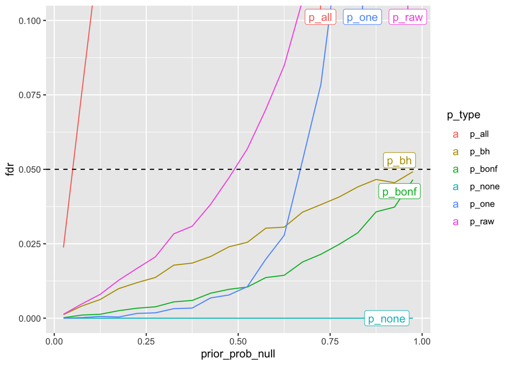

```r
rates_df %>%
  ggplot(aes(x = prior_prob_null, y = fdr, color = p_type)) +
  geom_line() +
  geom_hline(yintercept = 0.05, linetype = "dashed") +
  geom_label_repel(aes(label = p_type), data = . %>% group_by(p_type) %>% slice(n())) +
  coord_cartesian(ylim = c(0, .1))
```

Only Bonferroni controls familywise error rate (FWER):

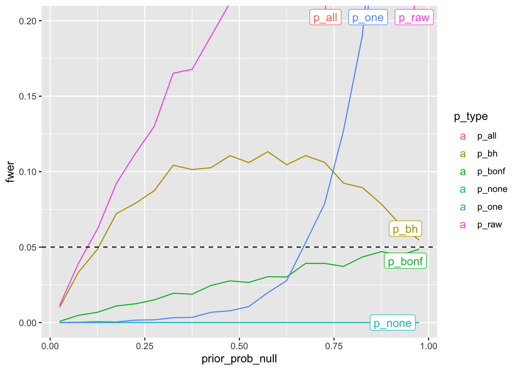

```r
rates_df %>%
  ggplot(aes(x = prior_prob_null, y = fwer, color = p_type)) +
  geom_line() +
  geom_hline(yintercept = 0.05, linetype = "dashed") +
  geom_label_repel(aes(label = p_type), data = . %>% group_by(p_type) %>% slice(n())) +
  coord_cartesian(ylim = c(0, .2))
```

### Payoffs

Mean payoff by incentive structure and p value correction type:

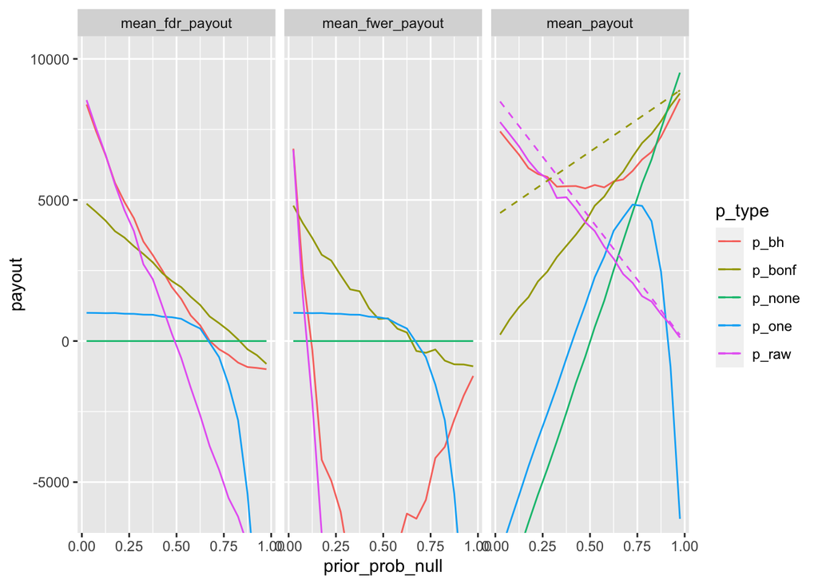

```r
rates_df %>%
  gather(payout_type, payout, mean_payout, mean_fdr_payout, mean_fwer_payout) %>%
  filter(p_type != "p_all") %>%
  ggplot(aes(x = prior_prob_null, y = payout, color = p_type)) +
  geom_line() +
  facet_wrap(~ payout_type) +
  stat_function(aes(color = "p_raw"),
    fun = ~ E_payoff_raw(alpha, n = n_panels, p_null = .x, mu = 1, sigma = 1, K = n_obs),
    linetype = "dashed", data = . %>% filter(payout_type == "mean_payout")) +
  stat_function(aes(color = "p_bonf"),
    fun = ~ E_payoff_raw(alpha / n_panels, n = n_panels, p_null = .x, mu = 1, sigma = 1, K = n_obs),
    linetype = "dashed", data = . %>% filter(payout_type == "mean_payout")) +
  coord_cartesian(ylim = c(-6000, 10000))
```

We can see that under the incentive structure that uses all four corners of the payoff matrix (`mean_payout` column), the Benjamini-Hochberg procedure seems to do well overall.

We can also see from the dashed lines that the analytical solution does not quite line up with this.

And here are the payouts averaged over the prior probability of the null:

```r
rates_df %>%
  gather(payout_type, payout, mean_payout, mean_fdr_payout, mean_fwer_payout) %>%
  group_by(p_type, payout_type) %>%
  summarise(payout = mean(payout)) %>%
  spread(payout_type, payout)
```

```
## # A tibble: 6 x 4
## # Groups:   p_type [6]
##   p_type mean_fdr_payout mean_fwer_payout mean_payout
##   <chr>            <dbl>            <dbl>       <dbl>
## 1 p_all          -90051.         -172060    -90051.
## 2 p_bh             2342.           -4147.     6302.
## 3 p_bonf           2006.            1183.     4499.
## 4 p_none              0                0         5.14
## 5 p_one           -1182.           -1182.     -395.
## 6 p_raw            -313.          -12732.     3923.
```

We see that Benjamini-Hochberg does best with the FDR payout scheme (the two corners) and the payout scheme with all parts of the confusion matrix incentivized (last column). Bonferroni does best with the FWER payout scheme (all-or-nothing payout based on the number of rejections and whether they were all correct rejections or not).